# PsychoPy - Scheduling and Recording

March 20, 2018

## Previous HomeWork

- Drawing blank screen

```python
    window.flip() # refresh the window
    psychopy.core.wait(ISI) # inter-stimuli-interval
```

1. But where to put it.
   - After the stimulus display, of course.
2. Identifying which part of the code is responsible of presenting the stimulus.

```python
for i in range(setsize):
    stim = psychopy.visual.TextStim(window, text = stimuli[i])
    stim.draw()
    window.flip()
    psychopy.core.wait(display_duration)
```

- Considering adding a comment if you can't identify it.

## Level of Processing

- Typical long-term memory study by Craik & Lockhart (1972)
- Show a long list of words
- After each word display, participants are asked to 'process' the word, e.g.,
  - Phonemic
  - Categorical
  - Sentence
- Later there will be a recall/recognition task.

## Level of Processing

- Let's do a short-term memory version.
- What we have now:

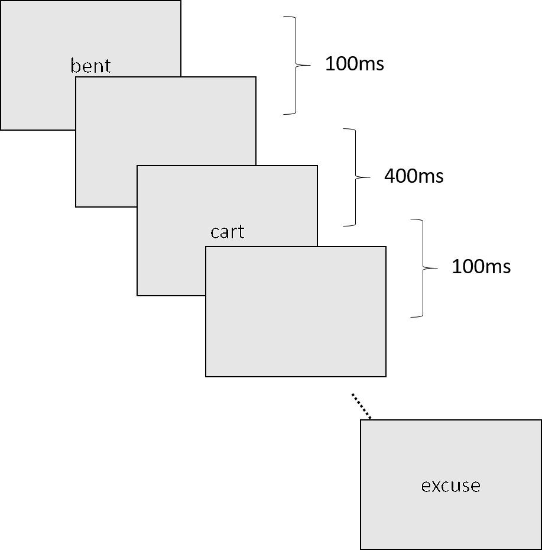

- Add recording after each stimulus display

## Level of Processing

```python
response = psychopy.event.waitKeys(keyList = ['c', 'a'])
```

- Previously, we used waitKeys.
- Let's try it. level_of_processing1.py

## Level of Processing

- Problems:
  1. Response isn't accepted during `psychopy.core.wait()` period.
  2. Participants are able to hold on responding to see the stimulus as long as they want.
- Core issue: The display and recording should run parallel.

## Level of Processing

- Check psychopy.event.waitKeys.
  - maxWait

```python
    stim = psychopy.visual.TextStim(window, text = stimuli[i])
    stim.draw()
    window.flip()
    #psychopy.core.wait(display_duration)

    response = psychopy.event.waitKeys(maxWait = display_duration, keyList = ['c', 'a'])
```

- Didn't solve the problem entirely.
- Participants can spam response to shortern the stimulus display

## Level of Processing

- Get the reaction time of the response, and add the missing time back after response.
- There are two ways:
  1. use `timeStamped = True`
  2. use psychopy.core.getTime

```python
    t0 = psychopy.core.getTime()
    response = psychopy.event.waitKeys(maxWait = display_duration, keyList = ['c', 'a'])
    reaction_time = psychopy.core.getTime() - t0
    psychopy.core.wait(display_duration - reaction_time)
```

- Are we there yet?

## IF

- If participants failed to respond in time, `psychopy.event.waitKeys` returns None instead of actual key press.
- Keep checking if the response is `None`.

```python
    if response is None:
        # have to check for more response
    else:
        # don't have to check
```

```python
    if response == 'a':
        # participant pressed 'a', do something about this
```

- `is` checks if the variables are referecing to the same object
- `==` checks if the variables have the same value.
- `None` is a special case which you HAVE TO check with is.

## IF

- Other logical operation

```python
    response is not None
    response != 'c'
    not response == 'c'
    response == 'c' and response_time < 0.5
    response is None or response_time < 0.1
```

- Back to level of processing experiment

## Surprised Exercise

- Now you know everything you need to finish the experiment.
- DOOOO IIIIIT.

## Level of Processing

```python
    window.flip() # present blank screen regardless

    if response is None:
        # participant failed to give the response during the stimulus onset
        # keep recording the response
        response = psychopy.event.waitKeys(maxWait = ISI, keyList = ['o', 'n'])

        reaction_time = psychopy.core.getTime() - t0
        psychopy.core.wait(ISI - reaction_time - display_duration)
    else:
        # participant gave response during stimulus onset
        # wait patiently
        psychopy.core.wait(ISI)
```

## Level of Processing

- This is not over yet, my summer child.
  - Everytime, `response` and `reaction_time` are overwritten by new input.
  - You have to somehow remember the response and rt.
- Create an (or two) array to store the result.

```python
stimuli = ['bent',
           'cart',
           'line',
           'birth',
           'ultra',
           'excuse']
```

## No longer a surprise exercise

- That's the homework! Store the response and RT somewhere and output them in the end of experiment.
  - If you are stuck, try to Goole `python how to create an array with n elements`
  - You can use `print` to output.